# Materials_methods_EDA_gum

Etienne Rolland

13/11/2019

# Introduction

This report is the first one to document and study the feasability of the automatic quality evaluation of experimental literature investigating bio–nano interactions. The first step of this automatic evaluation is to isolate the section Materials and Methods. The goal is to use later this section only to assess if the characterisation of the nano-materials is done and ebaluate the quality of the articles.

This report contain preliminary analyses and exploration of the data contained in the corpus of text. The first goal of this analyses is to gain some understanding of the structure of the texts inside the corpus of articles and the relations of the lemmas “material(s)” and “method(s)” to this corpus.

The second goal is to investigate how to discriminate the beginning of the section “Materials and methods”. The main problem to identify entry of the section Materials and Methods is that some of this two words can be present in the text of the article (typically “cf” material and methods").

The corpus of text has been created from the 751 articles from the folder “Full Text dev set”, which contain 751 articles converted into txt file format. The others articles are kept unseen to test the efficacy of any other tools developped later in “real life condition”.

Few definitions to frame the problem :

- Token : Word form or punctuation symbol. “,”, “(” are tokens, but also “and” or “method”.
- Lemma : Lemma or stem of word form. “Materials” and “materials” token have the same lemma “materials”, for example.
- Head : Head of the current word, which is either a value of token_id or zero.

In the later section, we will try differents criteria to isolate some lemmas “materials”, “material”, “methods” and “method”. We will use a technic, co-occurences, to explore the surronding of the differents lemmas in the text and evaluate if this criteria allow to discriminate the beginning of the section materials and methods from the remaining of the article.

## R Markdown

This is an R Markdown document. Markdown is a simple formatting syntax for authoring HTML, PDF, and MS Word documents. It is a good way to create informal reports describing data analysis projects as a web page, and a good way to mix code and description in a readable maner. There is even books in this format, ranging from [Data Analysis for the Life Sciences](http://www.rwdc2.com/files/rafa.pdf) to [Text Mining with R, A Tidy Approach](https://www.tidytextmining.com/), so anybody can understand and retake this work. This report is also code, it can be recompiled with new data (including an other model for the annotation of the corpus).

## Import and datastructure

```r
library(udpipe)
library(lattice)
library(wordcloud)
library(igraph)
library(ggraph)
library(ggplot2)
library(dplyr)
```

The following lines load the corpus of text, already annotated and tokenized :

```r
x <- readRDS(file = "annotation_gum.rds")
x <- as.data.frame(x)
length(unique(x$doc_id))
```

```
## [1] 751
```

# Words with head_token_id == 0

Considering the observation that, in “Materials and Methods” the head_token_ID was 0 for the token “Materials”, one idea was to explore what are, in the corpus of texts, the most common lemma with a head_token_ID equal to zero.

The expected outcome of this analysis could be to retrieve the usual sections title of scientific articles inside the most common words, like Abstract or Results. The goal is to assess if it is a consistent property of the titles of section inside the articles and uncover potential synonyms to “materials and methods” like “experimental section”.

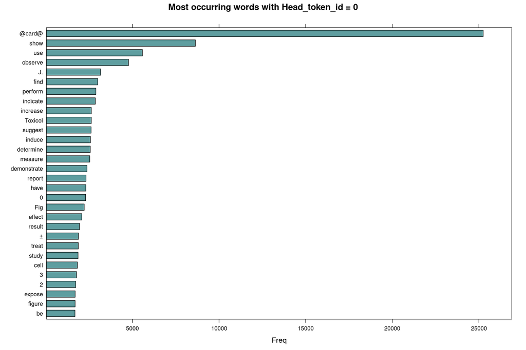

```r
stats <- subset(x, head_token_id == 0) #https://bnosac.github.io/udpipe/docs/doc7.html
stats <- txt_freq(x = stats$lemma)

stats$key <- factor(stats$key, levels = rev(stats$key))
barchart(key ~ freq, data = head(stats, 30), col = "cadetblue", main = "Most occurring words with Head_token_id = 0", xlab = "Freq")
```

Nonetheless, it seems that this assumption was quite naive, as lot of token have this property. Let’s filter for specific lemmas that correspond to usual title of section, like abstract of results :

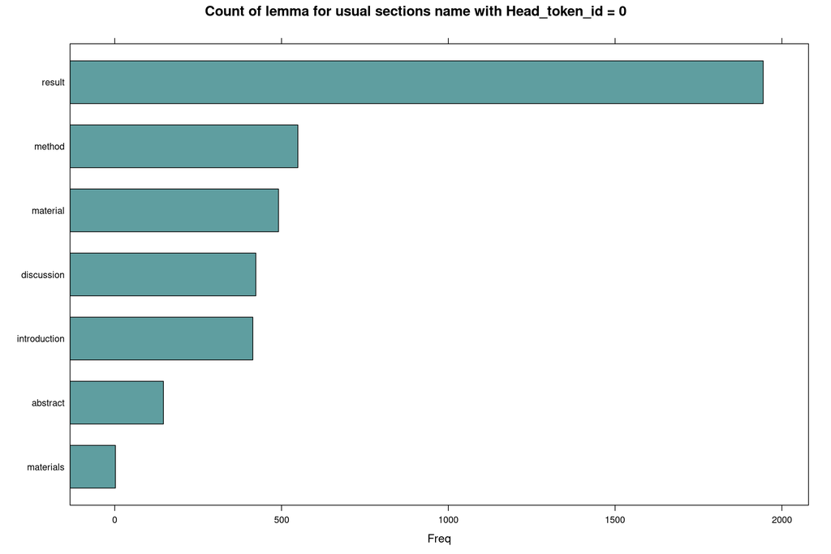

```r
stats<-stats %>% filter(key %in% c("material", "materials", "result", "results", "abstract", "introduction" , "method", "methods", "discussion", "references"))

stats$key <- factor(stats$key, levels = rev(stats$key))
barchart(key ~ freq, data = head(stats, 30), col = "cadetblue", main = "Count of lemma for usual sections name with Head_token_id = 0", xlab = "Freq")
```

```r
stats
```

```
##            key freq     freq_pct
## 1       result 1944 0.3865249144
## 2       method  549 0.1091574990
## 3     material  491 0.0976253770
## 4   discussion  423 0.0841049582
## 5 introduction  414 0.0823154910
## 6     abstract  146 0.0290291345
## 7    materials    2 0.0003976594
```

Some section titles seems to have the afored mentionned property. Nonetheless, the number does not match the total number of articles in this corpus (751). To take the example of the token discussion, or some articles does not have a section dicussion, or, more probably, the token discussion does not have the property mentionned earlier. We can answer this question :

```r
occurrences<-which(x$lemma=="discussion")
length(occurrences)
```

```
## [1] 897
```

```r
length(unique(x[occurrences,]$doc_id))
```

```
## [1] 707
```

There is 897 occurrences of the word discussion in all the corpus, and 707 article with this word. It seems really likely that discriminating tokens that are section titles just with a head token ID of zero is not sufficient.

## Visualize the most recurent head_token_id of the lemma material, materials, method and methods

To explore the relationships of the lemmas “material(s)” and “method(s)” with the rest of the corpus, we can analyse what are the most recurents head tokens for the lemmas “material” and “materials”. The goals of the analysis are :

- to observe if the lemma “material(s)” is often associated as head with the lemma “material(s)” and with which frequency
- to observe what are the other lemma that are commonly the head of the lemma material(s)
- same question(s) for the lemma “method” and “methods”

### Lemma material

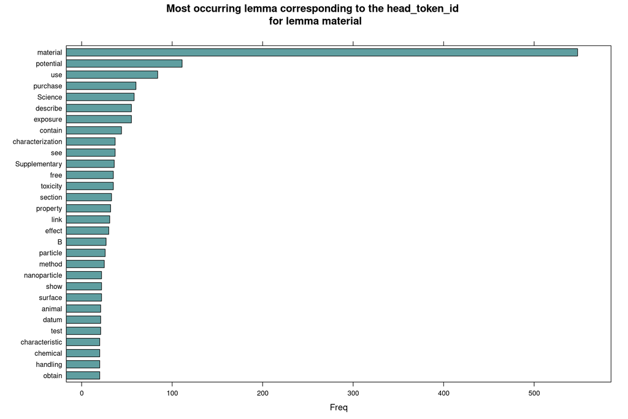

```r
grep_lemma_head_token_id <- function(index){
  #catch the lemma corresponding to the head_token_id of the token at the entry "index" of x
  #x[index,] return a token and all the associated data : lemma, but also sentence and doc_id
  occurrence<-x[index,] #x[index,], where x is the dataframe of annotation generated by udpipe
  head_token_id<-occurrence$head_token_id
  head_token_id<-as.numeric(head_token_id)
  sentence_id<-occurrence$sentence_id
  doc_id<-occurrence$doc_id
  #the following line query the lemma of the head_token_id based on the previous parameters
  lemma_head_token_id<-x[which(x$sentence_id==sentence_id & x$doc_id==doc_id)[head_token_id],]$lemma
  if (head_token_id==0) {lemma_head_token_id=occurrence$lemma}
  return(lemma_head_token_id)
}

material_occurrences<-which(x$lemma=="material")
head_token_lemmas<-sapply(material_occurrences, grep_lemma_head_token_id)
mytable<-table(head_token_lemmas)
stats<-as.data.frame(mytable)

stats<-stats[order(stats$Freq, decreasing = TRUE),]
stats$key <- factor(stats$head_token_lemmas, levels = rev(stats$head_token_lemmas))
barchart(key ~ Freq, data = head(stats, 30), col = "cadetblue", main = "Most occurring lemma corresponding to the head_token_id \n for lemma material", xlab = "Freq")
```

### Lemma materials

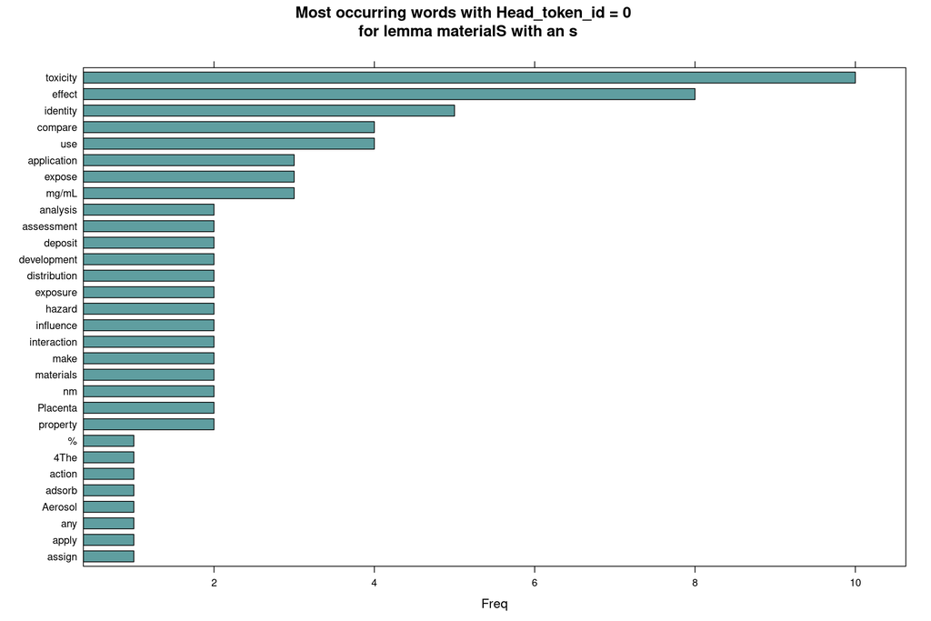

```r
occurrences<-which(x$lemma=="materials")

head_token_lemmas<-sapply(occurrences, grep_lemma_head_token_id)
mytable<-table(head_token_lemmas)
stats<-as.data.frame(mytable)

stats<-stats[order(stats$Freq, decreasing = TRUE),]
stats$key <- factor(stats$head_token_lemmas, levels = rev(stats$head_token_lemmas))
barchart(key ~ Freq, data = head(stats, 30), col = "cadetblue", main = "Most occurring words with Head_token_id = 0 \n for lemma materialS with an s", xlab = "Freq")
```

### Lemma method

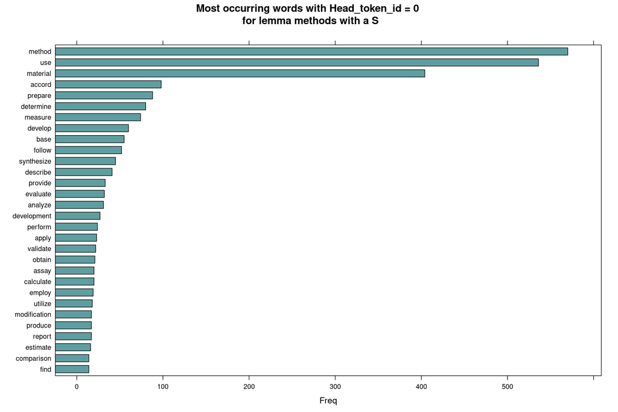

```r
occurrences<-which(x$lemma=="method")

head_token_lemmas<-sapply(occurrences, grep_lemma_head_token_id)
mytable<-table(head_token_lemmas)
stats<-as.data.frame(mytable)


stats<-stats[order(stats$Freq, decreasing = TRUE),]
stats$key <- factor(stats$head_token_lemmas, levels = rev(stats$head_token_lemmas))
barchart(key ~ Freq, data = head(stats, 30), col = "cadetblue", main = "Most occurring words with Head_token_id = 0 \n for lemma methods with a S", xlab = "Freq")
```

### Lemma methods

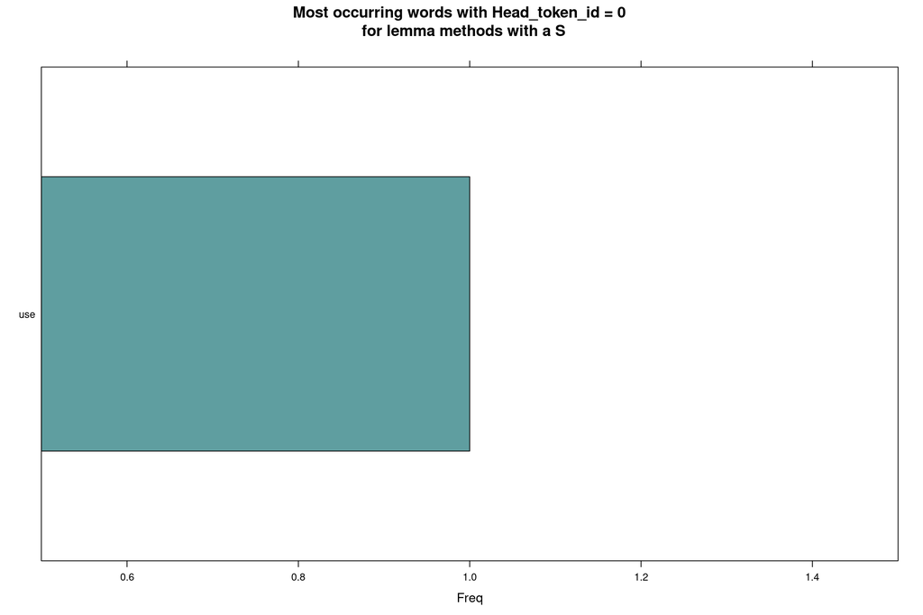

```r
occurrences<-which(x$lemma=="methods")

head_token_lemmas<-sapply(occurrences, grep_lemma_head_token_id)
mytable<-table(head_token_lemmas)
stats<-as.data.frame(mytable)


stats<-stats[order(stats$Freq, decreasing = TRUE),]
stats$key <- factor(stats$head_token_lemmas, levels = rev(stats$head_token_lemmas))
barchart(key ~ Freq, data = head(stats, 30), col = "cadetblue", main = "Most occurring words with Head_token_id = 0 \n for lemma methods with a S", xlab = "Freq")
```

```r
head(stats, 10)
```

```
##   head_token_lemmas Freq key
## 1               use    1 use
```

# Co-occurences

## Co-occurences for material(s) and method(s)

In the next sessions we test differents criteria to discriminate the lemmas “materials” and “material” inside the articles. The idea is to find a criteria that allow to identify the beginning of the section “materials and methods”.

Co-occurrence is an analysis that allow to see how words are used either in the same sentence or next to each other. We will use this approach to have a sense of what is the neighbourhood of the lemmas we isolated based on each criteria.

There is several type of cooccurrences analysis : * Looking at which words are located in the same document/sentence/paragraph. * Looking at which words are followed by another word. * Looking at which words are in the neighbourhood of the word as in follows the word within skipgram number of words.

[Cf doc of the package Updipe](https://rdrr.io/cran/udpipe/man/cooccurrence.html) for the three possible use. We will use the second approach, as it is the most relevant to our goal and as it is the most simple to interpret. Differents skipgram can be used to got an idea of the distance or more proximal neighbourhood.

The two function above are meant to gain some place in the document. The first one plot the word network, a common technique to visualise word cooccurrences, after the filtration of the cooccurrences that concerns only the lemma of interrest.

```r
plot_cooccurrence <- function(stats, lemma, title){
  #function to gain place and make this Rmarkdown document more clear
  stats <- stats %>% filter(term1 %in% c(lemma) | term2 %in% c(lemma))
  wordnetwork <- head(stats, 30)
  wordnetwork <- graph_from_data_frame(wordnetwork)
  ggraph(wordnetwork) +
    geom_edge_link(aes(width = cooc, edge_alpha = cooc), edge_colour = "pink") +
    geom_node_text(aes(label = name), col = "blue", size = 5) +
    theme_graph(base_family = "Helvetica") +
    theme(legend.position = "none") +
    labs(title = title)
}
```

```r
head_cooc <- function(stats, lemma){
  #function to gain place and make this Rmarkdown document more clear
  stats <- stats %>% filter(term1 %in% c(lemma) | term2 %in% c(lemma))
  head(stats, 30)
}
```

```r
stats <- cooccurrence(x = x$lemma, skipgram = 0)
```

Bigger skipgram were not really relevant. Here we can simply count the elements of the dataframe stats to see how many times each word follow each other.

```r
# plot_cooccurrence(stats, lemma="materials", title="Co-occurences for the lemma materials")
# head_cooc(stats, lemma="materials")
```

```
## Using `stress` as default layout
```

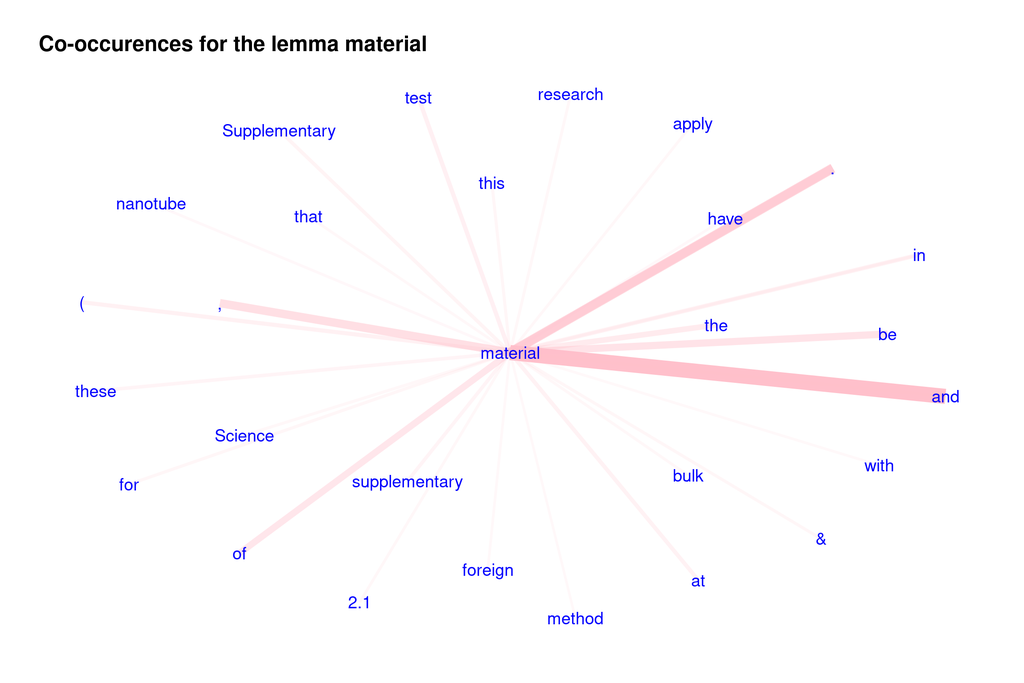

```r
plot_cooccurrence(stats, lemma="material", title="Co-occurences for the lemma material")
```

```r
head_cooc(stats, lemma="material")
```

```
##            term1    term2 cooc
## 1       material      and  804
## 2              . material  474
## 3       material        .  396
## 4       material        ,  393
## 5       material       be  327
## 6             of material  288
## 7            the material  229
## 8           test material  151
## 9       material       in  148
## 10      material        (  141
## 11      material       at  135
## 12 Supplementary material  109
## 13         these material  105
## 14 supplementary material  105
```

[output cut: 16 more lines]

```
## Using `tree` as default layout
```

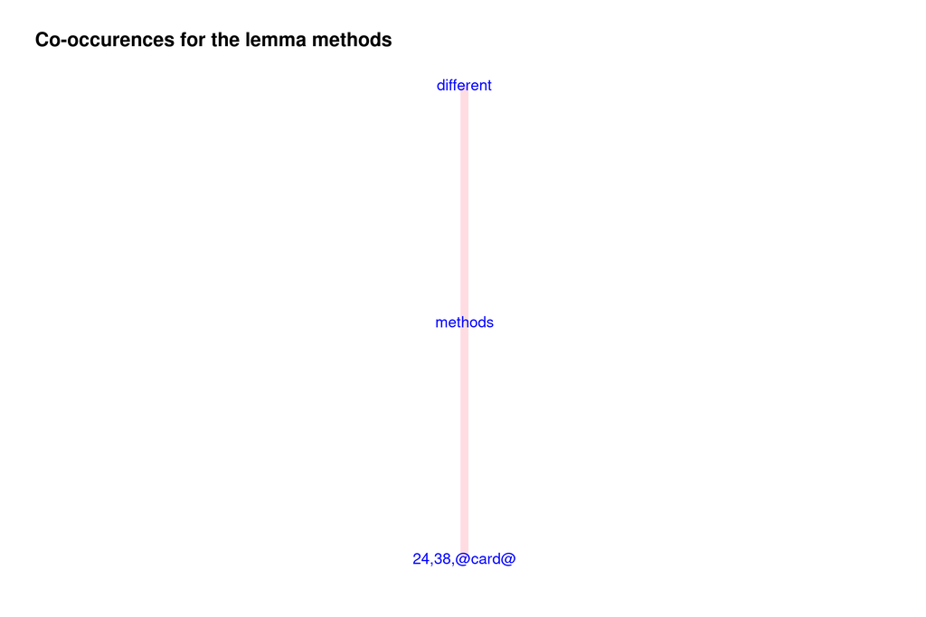

```r
plot_cooccurrence(stats, lemma="methods", title="Co-occurences for the lemma methods")
```

```r
head_cooc(stats, lemma="methods")
```

```
##      term1        term2 cooc
## 1 diﬀerent      methods    1
## 2  methods 24,38,@card@    1
```

```
## Using `stress` as default layout
```

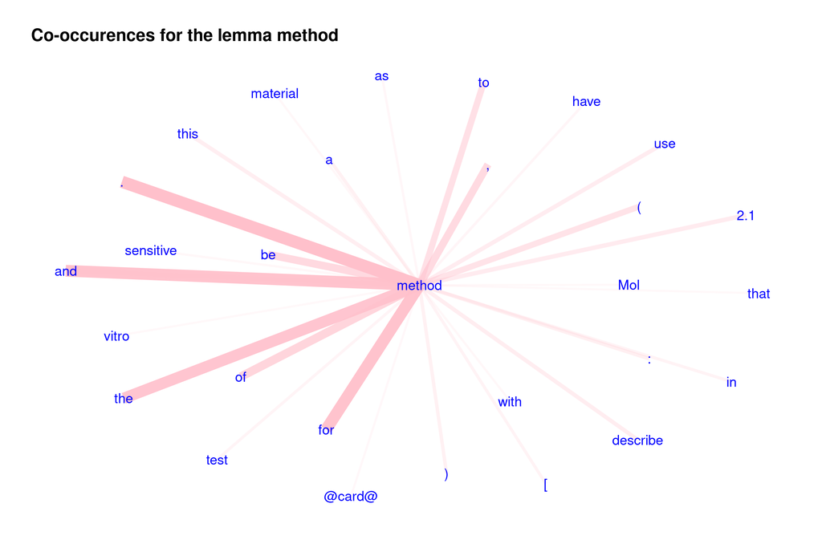

```r
plot_cooccurrence(stats, lemma="method", title="Co-occurences for the lemma method")
```

```r
head_cooc(stats, lemma="method")
```

```
##        term1    term2 cooc
## 1     method        .  477
## 2        and   method  458
## 3     method      for  457
## 4        the   method  437
## 5          .   method  415
## 6     method       of  315
## 7     method       be  279
## 8     method        ,  272
## 9     method       to  225
## 10    method        (  207
## 11    method      2.1  138
## 12    method      and  134
## 13    method      use  129
## 14    method describe  121
```

[output cut: 16 more lines]

## Co-occurences, visualization of all the lemma of interest

```
## Using `stress` as default layout
```

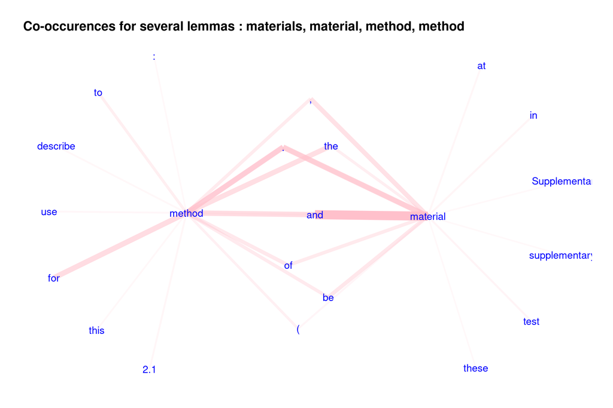

```r
plot_cooccurrence(stats, lemma=c("materials", "material", "methods", "method"), title="Co-occurences for several lemmas : materials, material, method, method")
```

```r
head_cooc(stats, lemma=c("materials", "material", "methods", "method"))
```

```
##            term1    term2 cooc
## 1       material      and  804
## 2         method        .  477
## 3              . material  474
## 4            and   method  458
## 5         method      for  457
## 6            the   method  437
## 7              .   method  415
## 8       material        .  396
## 9       material        ,  393
## 10      material       be  327
## 11        method       of  315
## 12            of material  288
## 13        method       be  279
## 14        method        ,  272
```

[output cut: 16 more lines]

## Co-occurences for materials and material when their head_token_id = 0

Similar to the previous approach, we want to explore the relationships of the differents lemma with their neighbourhood in the corpus of text, but we restrict the analysis for sentences for which the lemma material or materials is the head token of itself.

Even if not all the “Materials and Methods” section titles has a “materials” lemma with a head_token_id equal to zero, the opposite could be true.

Here, by restricting to the lemmas “materials” and “material” which have a head_token_id = 0, we can visualize their statistical association with other words and understand if this subsets of token is really delimiting the beginning of section “material and methods”.

The first function allow to filter for sentences where the lemma material or materials is the head. The following lines calculate the co-occurrences and draw the plot as previously.

```r
create_subset_corpus<- function(index){
  #this function is aimed to help construct a subset of x for the part of the analysis :
  #Co-occurences for materials and material when their head_token_id = 0
  #x[index,] return a token and all the associated data : lemma, but also sentence and doc_id
  occurrence<-x[index,] #x[index,], where x is the dataframe of annotation generated by udpipe
  sentence_id<-occurrence$sentence_id
  doc_id<-occurrence$doc_id
  #the following lines collect the head_token_id and test if is equal to zero
  #if so, its output the tokens of the sentences
  head_token_id<-occurrence$head_token_id
  if (head_token_id==0) {return(strip_corpus(doc_id, sentence_id))}
  return()
}

strip_corpus <- function(doc_id, sentence_id){
  #this function returns all the lemma of a sentence, in the appropriate format
  #the purpose of doing so is to allow for calculation of cooccurence of words inside this sentences
  #for this we need all the elements of the sentence
  sentence_id<-as.numeric(sentence_id)
  subset_article<-x[which(x$sentence_id==sentence_id & x$doc_id==doc_id),]
  return(subset_article)
}
```

```
## Using `tree` as default layout
```

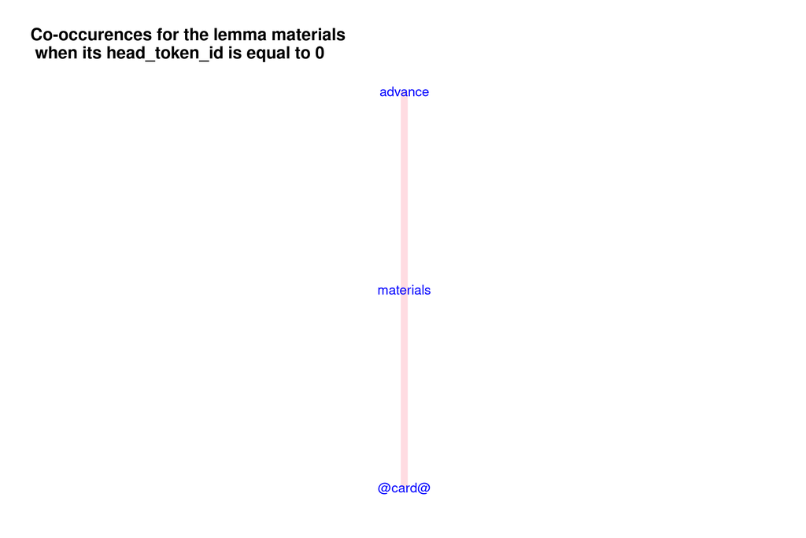

```r
occurrences<-which(x$lemma=="materials")
subset_corpus<-sapply(occurrences, function(index) create_subset_corpus(index))
subset_corpus<-do.call(rbind, subset_corpus)

stats <- cooccurrence(x = subset_corpus$lemma, skipgram = 0)
plot_cooccurrence(stats, lemma="materials", title="Co-occurences for the lemma materials \n when its head_token_id is equal to 0")
```

```r
head_cooc(stats, lemma="materials")
```

```
##       term1     term2 cooc
## 1   advance materials    2
## 2 materials    @card@    2
```

```
## Using `tree` as default layout
```

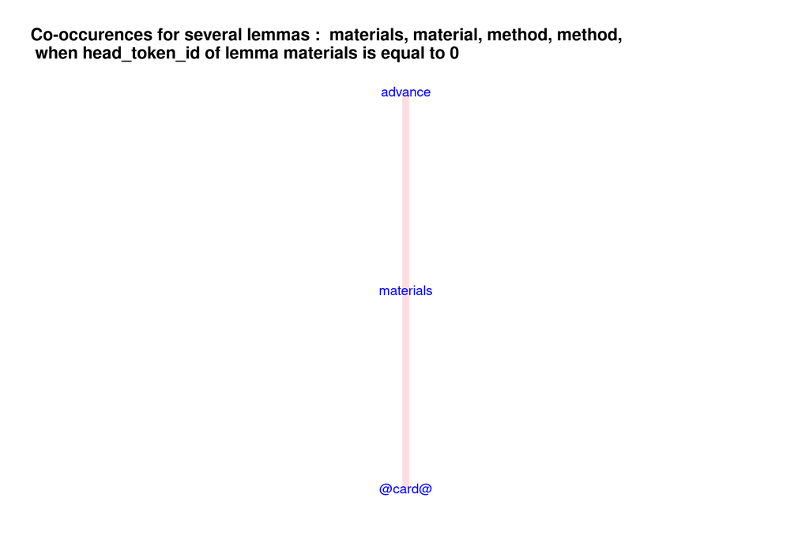

```r
plot_cooccurrence(stats, lemma=c("materials", "material", "methods", "method"), title="Co-occurences for several lemmas :  materials, material, method, method, \n when head_token_id of lemma materials is equal to 0")
```

```r
head_cooc(stats, lemma=c("materials", "material", "methods", "method"))
```

```
##       term1     term2 cooc
## 1   advance materials    2
## 2 materials    @card@    2
```

```
## Using `stress` as default layout
```

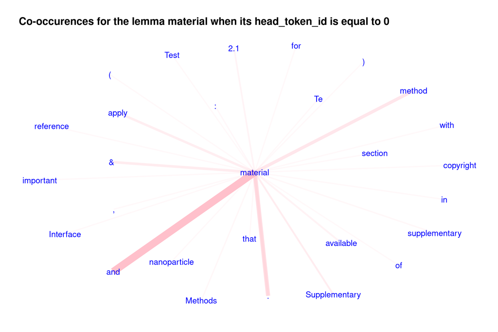

```r
occurrences<-which(x$lemma=="material")
subset_corpus<-sapply(occurrences, function(index) create_subset_corpus(index))
subset_corpus<-do.call(rbind, subset_corpus)

stats <- cooccurrence(x = subset_corpus$lemma, skipgram = 0)
plot_cooccurrence(stats, lemma="material", title="Co-occurences for the lemma material when its head_token_id is equal to 0")
```

```r
head_cooc(stats, lemma="material")
```

```
##            term1         term2 cooc
## 1       material           and  238
## 2              .      material  117
## 3         method      material   79
## 4       material             &   54
## 5          apply      material   47
## 6       material             .   44
## 7  Supplementary      material   32
## 8       material      material   30
## 9       material     available   26
## 10           2.1      material   20
## 11 supplementary      material   10
## 12       Methods      material    9
## 13             :      material    8
## 14      material            in    7
```

[output cut: 16 more lines]

```
## Using `stress` as default layout
```

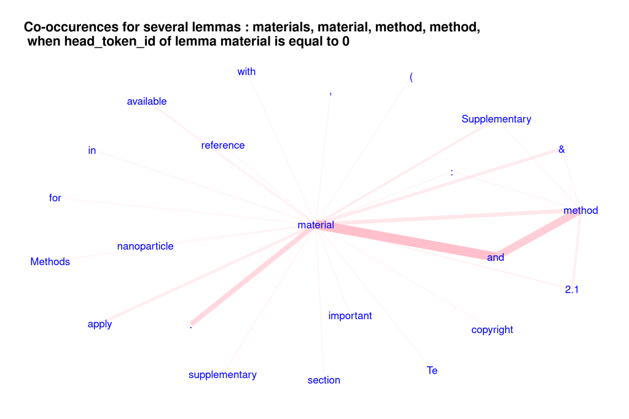

```r
plot_cooccurrence(stats, lemma=c("materials", "material", "methods", "method"), title="Co-occurences for several lemmas : materials, material, method, method, \n when head_token_id of lemma material is equal to 0")
```

```r
head_cooc(stats, lemma=c("materials", "material", "methods", "method"))
```

```
##            term1         term2 cooc
## 1       material           and  238
## 2            and        method  183
## 3              .      material  117
## 4         method      material   79
## 5       material             &   54
## 6          apply      material   47
## 7       material             .   44
## 8         method           2.1   39
## 9  Supplementary      material   32
## 10      material      material   30
## 11      material     available   26
## 12           2.1      material   20
## 13 supplementary      material   10
## 14       Methods      material    9
```

[output cut: 16 more lines]

## Co-occurences for methods and method when their head_token_id = 0

```r
occurrences<-which(x$lemma=="methods")
subset_corpus<-sapply(occurrences, function(index) create_subset_corpus(index))
subset_corpus<-do.call(rbind, subset_corpus)
#
# stats <- cooccurrence(x = subset_corpus$lemma, skipgram = 0)
# plot_cooccurrence(stats, lemma="methods", title="Co-occurences for the lemma methods \n when its head_token_id is equal to 0")
#head_cooc(stats, lemma="methods")
```

```r
# plot_cooccurrence(stats, lemma=c("materials", "material", "methods", "method"), title="Co-occurences for several lemmas : materials, material, method, method, \n when head_token_id of lemma methods is equal to 0")
# head_cooc(stats, lemma=c("materials", "material", "methods", "method"))
```

```
## Using `stress` as default layout
```

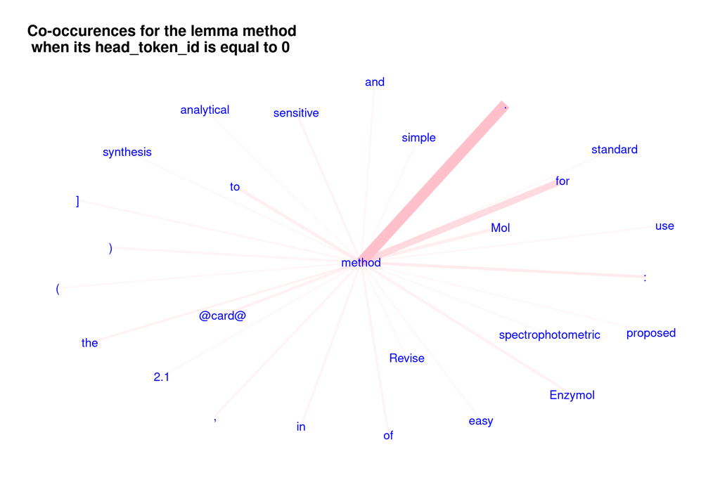

```r
occurrences<-which(x$lemma=="method")
subset_corpus<-sapply(occurrences, function(index) create_subset_corpus(index))
subset_corpus<-do.call(rbind, subset_corpus)

stats <- cooccurrence(x = subset_corpus$lemma, skipgram = 0)
plot_cooccurrence(stats, lemma="method", title="Co-occurences for the lemma method \n when its head_token_id is equal to 0")
```

```r
head_cooc(stats, lemma="method")
```

```
##                 term1     term2 cooc
## 1                   .    method  213
## 2              method       for  116
## 3              method         .   41
## 4              method       Mol   40
## 5              method        to   39
## 6              method         :   37
## 7              method    @card@   30
## 8              method    method   28
## 9              method   Enzymol   26
## 10          sensitive    method   22
## 11             method        of   22
## 12             method        in   20
## 13             method         ,   18
## 14                  )    method   17
```

[output cut: 16 more lines]

```
## Using `stress` as default layout
```

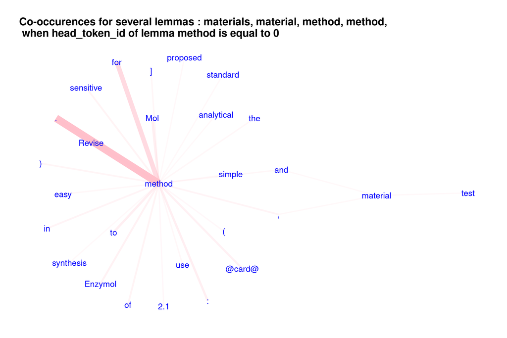

```r
plot_cooccurrence(stats, lemma=c("materials", "material", "methods", "method"), title="Co-occurences for several lemmas : materials, material, method, method, \n when head_token_id of lemma method is equal to 0")
```

```r
head_cooc(stats, lemma=c("materials", "material", "methods", "method"))
```

```
##         term1     term2 cooc
## 1           .    method  213
## 2      method       for  116
## 3      method         .   41
## 4      method       Mol   40
## 5      method        to   39
## 6      method         :   37
## 7      method    @card@   30
## 8      method    method   28
## 9      method   Enzymol   26
## 10  sensitive    method   22
## 11     method        of   22
## 12     method        in   20
## 13     method         ,   18
## 14          )    method   17
```

[output cut: 16 more lines]

## Co-occurences for materials and material when it is the last lemma of the document

We could assume that the last occurrence in an article of the lemma “materials” correspond to the section title “material and methods”. As before, we will use co-occurrences see how words are connected to the last occurrence of “materials” in each documents, and see how often it correspond to a “materials and methods” section.

The first two functions select the last occurrence of a word in a document, and got the id of their sentences. A graph showing the connection of words for this subset of sentences is then plot.

```r
create_subset_corpus_last_lemmas <- function(index){
  #this function is aimed to help construct a subset of x for the part of the analysis :
  #Co-occurences for materials and material when it is the last lemma of the document
  #x[index,] return a token and all the associated data : lemma, but also sentence and doc_id
  occurrence<-x[index,] #x[index,], where x is the dataframe of annotation generated by udpipe
  sentence_id<-occurrence$sentence_id
  doc_id<-occurrence$doc_id
  lemma<-occurrence$lemma
  occurrences_in_doc=which(x$doc_id==doc_id & x$lemma==lemma)
  last_occurrence=occurrences_in_doc[length(occurrences_in_doc)]
  if (last_occurrence==index){return(strip_corpus(doc_id, sentence_id))}
  return()
}
```

```r
# occurrences<-which(x$lemma=="materials")
# subset_corpus<-sapply(occurrences, function(index) create_subset_corpus_last_lemmas(index))
# subset_corpus<-do.call(rbind, subset_corpus)
#
# stats <- cooccurrence(x = subset_corpus$lemma, skipgram = 0)
# plot_cooccurrence(stats, lemma="materials", title="Co-occurences for the lemma materials \n when it is the last lemma of the document")
# head_cooc(stats, lemma="materials")
```

```r
# plot_cooccurrence(stats, lemma=c("materials", "material", "methods", "method"), title="Co-occurences for several lemmas : materials, material, method, method, \n when materials is the last lemma of the document")
# head_cooc(stats, lemma=c("materials", "material", "methods", "method"))
```

Annotated because of an error during compilation. No lemma materials are found using this approach.

```
## Using `stress` as default layout
```

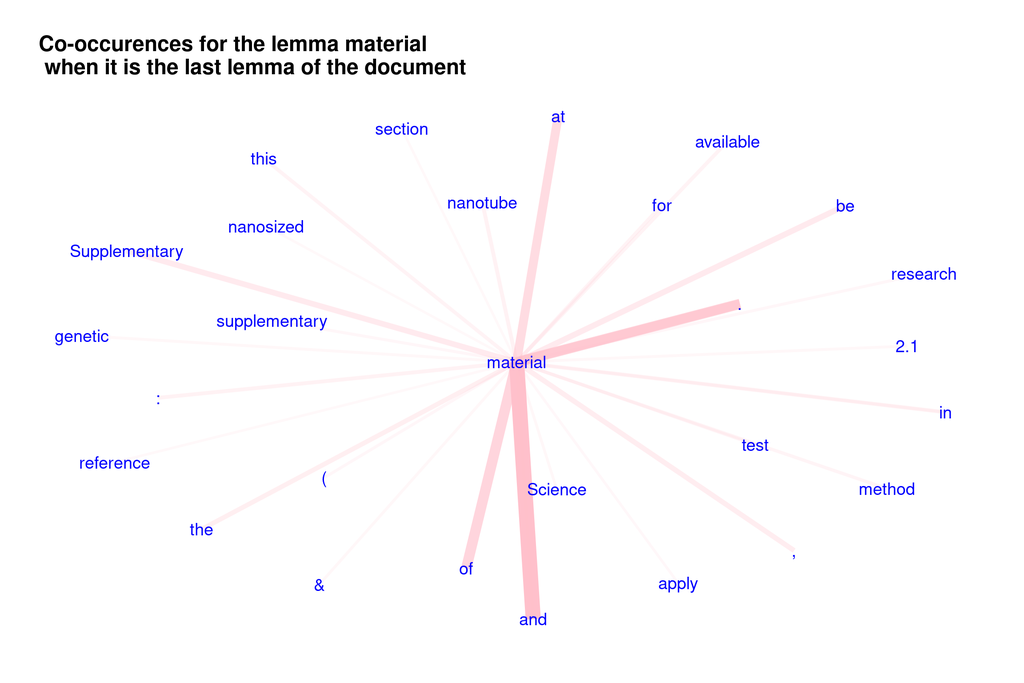

```r
occurrences<-which(x$lemma=="material")
subset_corpus<-sapply(occurrences, function(index) create_subset_corpus_last_lemmas(index))
subset_corpus<-do.call(rbind, subset_corpus)

stats <- cooccurrence(x = subset_corpus$lemma, skipgram = 0)
plot_cooccurrence(stats, lemma="material", title="Co-occurences for the lemma material \n when it is the last lemma of the document")
```

```r
head_cooc(stats, lemma="material")
```

```
##            term1     term2 cooc
## 1       material       and  160
## 2             of  material  102
## 3              .  material  101
## 4       material         .   87
## 5       material        at   84
## 6       material        be   46
## 7  Supplementary  material   45
## 8       material         ,   38
## 9            the  material   33
## 10      nanotube  material   24
## 11      material        in   23
## 12      material         :   23
## 13      material available   22
## 14      material       for   21
```

[output cut: 16 more lines]

```
## Using `stress` as default layout
```

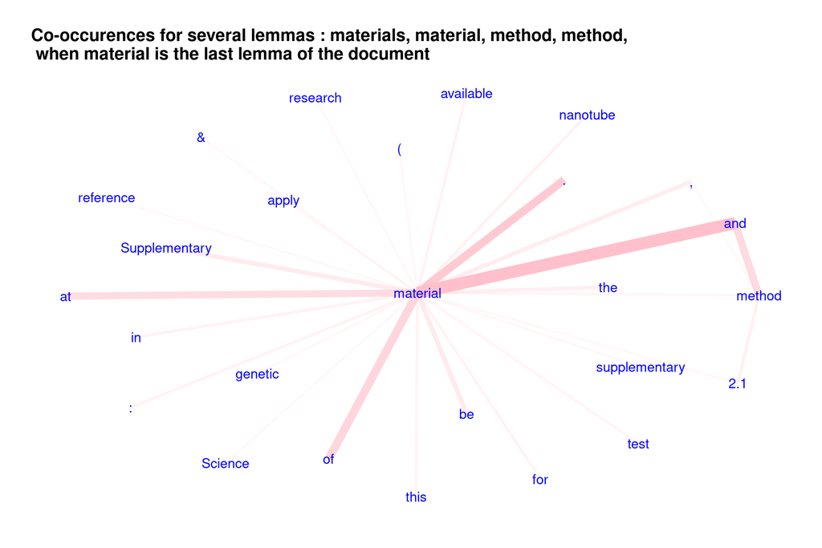

```r
plot_cooccurrence(stats, lemma=c("materials", "material", "methods", "method"), title="Co-occurences for several lemmas : materials, material, method, method, \n when material is the last lemma of the document")
```

```r
head_cooc(stats, lemma=c("materials", "material", "methods", "method"))
```

```
##            term1     term2 cooc
## 1       material       and  160
## 2             of  material  102
## 3              .  material  101
## 4            and    method   90
## 5       material         .   87
## 6       material        at   84
## 7       material        be   46
## 8  Supplementary  material   45
## 9       material         ,   38
## 10           the  material   33
## 11        method       2.1   28
## 12      nanotube  material   24
## 13      material        in   23
## 14      material         :   23
```

[output cut: 16 more lines]

## Co-occurences for lemma materials and material when they are the first lemma of a sentence

### Materials

```r
create_subset_corpus <- function(index, target){
  #this function is aimed to help construct a subset of x for the part of the analysis :
  #Co-occurences for lemma materials and material when they are the first lemma of a sentence
  #x[index,] return a token and all the associated data : lemma, but also sentence and doc_id
  occurrence<-x[index,] #x[index,], where x is the dataframe of annotation generated by udpipe
  sentence_id<-occurrence$sentence_id
  doc_id<-occurrence$doc_id
  #the following line query the first lemma of the sentence in the good document
  first_lemma<-x[which(x$sentence_id==sentence_id & x$doc_id==doc_id)[1],]$lemma
  if (first_lemma==target) {return(strip_corpus(doc_id, sentence_id))}
  return()
}
```

```r
occurrences<-which(x$lemma=="materials")
subset_corpus<-sapply(occurrences, function(index, target) create_subset_corpus(index, target),
                    target="materials")

subset_corpus<-do.call(rbind, subset_corpus)

# stats <- cooccurrence(x = subset_corpus$lemma, skipgram = 0)
# plot_cooccurrence(stats, lemma="materials", title="Co-occurences for lemma materials when it is the first lemma of a sentence")
#
head_cooc(stats, lemma="materials")
```

[output not shown]

```r
# plot_cooccurrence(stats, lemma=c("materials", "material", "methods", "method"), title="Co-occurences for several lemmas : materials, material, method, method, \n when lemma material is the first lemma of a sentence")
# head_cooc(stats, lemma=c("materials", "material", "methods", "method"))
```

### Material

```
## Using `stress` as default layout
```

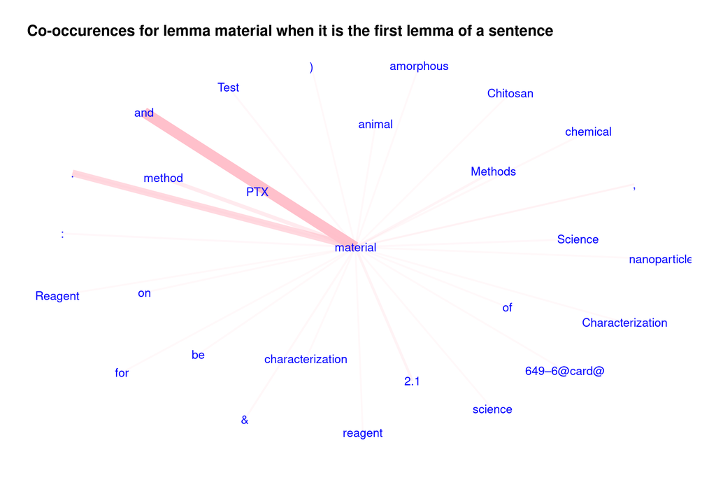

```r
occurrences<-which(x$lemma=="material")
subset_corpus<-sapply(occurrences, function(index, target) create_subset_corpus(index, target),
                    target="material")

subset_corpus<-do.call(rbind, subset_corpus)

stats <- cooccurrence(x = subset_corpus$lemma, skipgram = 0)
plot_cooccurrence(stats, lemma="material", title="Co-occurences for lemma material when it is the first lemma of a sentence")
```

```r
head_cooc(stats, lemma="material")
```

```
##               term1    term2 cooc
## 1          material      and  565
## 2                 . material  327
## 3            method material  144
## 4               2.1 material   60
## 5           Methods material   47
## 6          material material   35
## 7          material        .   22
## 8          material        &   16
## 9          chemical material   14
## 10                : material   13
## 11             Test material   13
## 12         material  Science   13
## 13           animal material    9
## 14         material        ,    9
```

[output cut: 16 more lines]

```
## Using `stress` as default layout
```

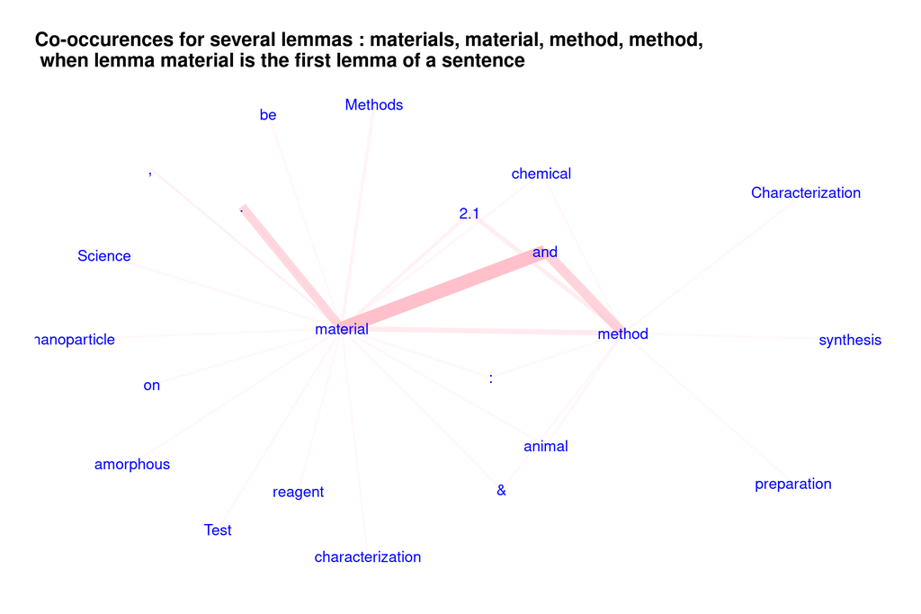

```r
plot_cooccurrence(stats, lemma=c("materials", "material", "methods", "method"), title="Co-occurences for several lemmas : materials, material, method, method, \n when lemma material is the first lemma of a sentence")
```

```r
head_cooc(stats, lemma=c("materials", "material", "methods", "method"))
```

```
##               term1            term2 cooc
## 1          material              and  565
## 2               and           method  378
## 3                 .         material  327
## 4            method         material  144
## 5            method              2.1  105
## 6               2.1         material   60
## 7           Methods         material   47
## 8          material         material   35
## 9          material                .   22
## 10           method           animal   20
## 11         material                &   16
## 12         chemical         material   14
## 13                :         material   13
## 14             Test         material   13
```

[output cut: 16 more lines]

# Conclusion

*GUM, the Georgetown University Multilayer corpus, is an open source collection of richly annotated web texts from multiple text types. The corpus is collected and expanded by students as part of the curriculum in the course LING-367 “Computational Corpus Linguistics” at Georgetown University. The selection of text types is meant to represent different communicative purposes, while coming from sources that are readily and openly available (usually Creative Commons licenses), so that new texts can be annotated and published with ease.*

The last criteria seems the most promising (using the first token of a sentence). This possibility to discriminate beginning of section is explored in an other report.